# Analyse de la table

Thomas Pilaud

28 octobre 2016

```r
require(knitr)
require(dplyr)
require(ggplot2)
require(reshape2)
library(data.table)
library(lubridate)
library(gridExtra)
```

```r
load("Donnees/df.octobre.RData")
```

# Quelques explorations

#### Analyse du champ ‘status’

```r
table(df.octobre$status)
```

```
##
##  CLOSED    OPEN
##   50116 2585350
```

```r
stations.fermees <- df.octobre %>%
  filter(status == "CLOSED") %>%
  distinct(number)
stations.fermees <- as.vector(t(stations.fermees))
length(stations.fermees)
```

```
## [1] 93
```

93 stations ont été fermées au moins une fois. On regarde si il y en a qui ont toujours été fermées.

```r
df.stations.fermees <- data.frame(table(df.octobre$number, df.octobre$status))
df.stations.fermees <- dcast(df.stations.fermees, Var1 ~ Var2, value.var = "Freq")
names(df.stations.fermees) <- c("number", "n_closed", "n_open")
df.stations.fermees <- df.stations.fermees %>%
  mutate(tx_closed = round(n_closed/(n_closed+n_open), 4)) %>%
  filter(number %in% stations.fermees)
summary(df.stations.fermees$tx_closed)
```

```
##    Min. 1st Qu.  Median    Mean 3rd Qu.    Max.
##  0.0005  0.0032  0.0913  0.2497  0.4036  1.0000
```

```r
sum(df.stations.fermees$tx_closed == 1)
```

```
## [1] 6
```

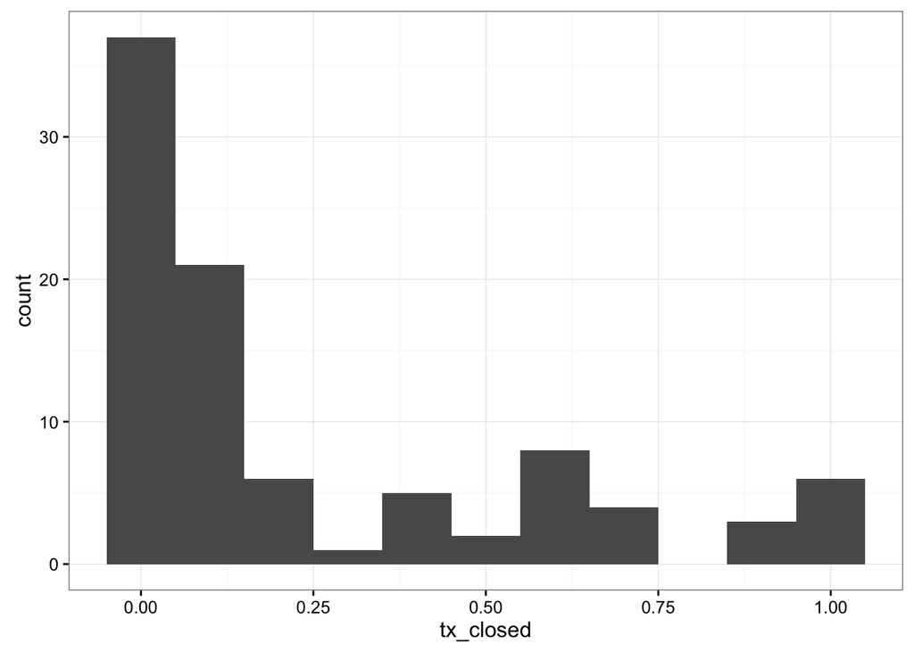

```r
ggplot(df.stations.fermees) + aes(x=tx_closed) + geom_histogram(binwidth = 0.1) + theme_bw()
```

Certaines stations sont tout le temps fermées. On pourra les éliminer.

```r
df.octobre.jms.fermees <- subset(df.octobre, !number %in% stations.fermees)
```

# Qualité de données

#### Vérification de l’absence de valeurs manquantes

```r
apply(df.octobre, 2, function(c) sum(is.na(c)))
```

```
##                status         contract_name         download_date
##                     0                     0                     0
##           bike_stands                number           last_update
##                     0                     0                     0
## available_bike_stands       available_bikes
##                     0                     0
```

#### Vérification des doublons

On regarde les doublons number x last_update

```r
sum(duplicated(df.octobre[,c("number", "last_update")]))
```

```
## [1] 11571
```

```r
stations.doublons <- unique(df.octobre[duplicated(df.octobre[,c("number", "last_update")]), c("number", "last_update")])
df.doublons <- inner_join(df.octobre, stations.doublons)
```

Si on enlève les stations fermées, ça ne change pas grand chose.

```r
sum(duplicated(df.octobre.jms.fermees[,c("number", "last_update")]))
```

```
## [1] 10141
```

En revanche, on a pas de doublons number x download_date

```r
sum(duplicated(df.octobre[,c("number", "download_date")]))
```

```
## [1] 0
```

Parfois, il n’y a pas de mise à jour (last_update) entre plusieurs téléchargements (download_date) consécutifs. On ne sait pas si c’est normal (il n’y a pas eu de mouvement sur la station ou pas). En d’autres termes, on se demande si quand il n’y a aucun mouvement, les informations sont mises à jour.

Pour répondre à cette question, on pourrait regarder si on a dans la table des exemples où le champ available_bikes ne change pas alors que last_udate change. Cependant, c’est peut-être parce qu’il y a eu du mouvement (une récupération ou une dépose de vélo) sans que cela ne change le nombre de vélos et de places disponibles. On ne peut donc pas répondre à cette question. Dans le doute, on considère qu’il n’y a pas d’anomalie, et donc on choisit d’utiliser le champ download_date.

On enlève les cas où le doublon est provoqué par une absence de mise à jour.

```r
df.octobre.dedoubl <- df.octobre %>%
  select(-download_date) %>%
  distinct
sum(duplicated(df.octobre.dedoubl[,c("number", "last_update")]))
```

```
## [1] 32
```

Il reste 32 doublons.

```r
stations.doublons <- unique(df.octobre.dedoubl[duplicated(df.octobre.dedoubl[,c("number", "last_update")]), c("number", "last_update")])
df.doublons <- inner_join(df.octobre, stations.doublons)
```

Il y a 6 stations pour lesquelles on a des informations contradictoires pour la même date de mise à jour (last_update).

#### Nombre d’enregistrements par jour

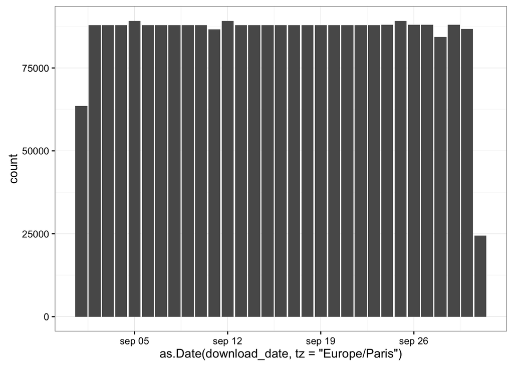

```r
ggplot(df.octobre) + aes(x=as.Date(download_date, tz="Europe/Paris")) + geom_bar() + theme_bw()
```

Pour l’instant on enleve le 1er et le dernier jour

```r
premier.jour <- as.Date("2016-09-01", format="%Y-%m-%d")
dernier.jour <- as.Date("2016-10-01", format="%Y-%m-%d")
df.octobre.cut <- df.octobre %>%
  mutate(download_date_trunc = as.Date(download_date, tz="Europe/Paris")) %>%
  filter(!download_date_trunc %in% c(premier.jour, dernier.jour))
```

On compte le nombre d’enregistrements par jour et par station

```r
nb.enreg <- df.octobre.cut %>%
  group_by(download_date_trunc, number) %>%
  summarise(nb_enreg = n()) %>%
  ungroup

summary(nb.enreg$nb_enreg)
```

```
##    Min. 1st Qu.  Median    Mean 3rd Qu.    Max.
##   27.00   72.00   72.00   71.93   72.00   73.00
```

```r
quantile(nb.enreg$nb_enreg, 0.01)
```

```
## 1%
## 69
```

On a dans le cas général 72 enregistrements par jour et par station, ce qui fait 1 enregistrement toutes les 20 minutes.

Délai maximum entre 2 enregistrements

```r
delai.enreg <- df.octobre %>%
  select(number, download_date) %>%
  group_by(number) %>%
  mutate(rank = row_number(download_date),
         prev_download_date = lag(download_date),
         download_date_trunc = as.Date(download_date, tz="Europe/Paris")) %>%
  ungroup %>%
  filter(rank != 1) %>%
  mutate(delai = as.numeric(difftime(download_date, prev_download_date, units="mins")))

# delai.enreg <- as.data.table(df.octobre)
# delai.enreg <- delai.enreg[, .(number, download_date)]
# delai.enreg[, yrrank:=rank(download_date,ties.method="first"),by=number]
# delai.enreg[, prev_download_date:= shift(download_date),by=number]
# delai.enreg[, delai:= as.numeric(difftime(download_date, prev_download_date, units="mins"))]
# delai.enreg <- setDT(delai.enreg)[, prev_download_date:= shift(download_date)][]

summary(delai.enreg$delai)
```

```
##    Min. 1st Qu.  Median    Mean 3rd Qu.    Max.
##  -40.83   19.98   20.00   20.02   20.02   80.05
```

```r
# ggplot(delai.enreg) + aes(x=delai) + geom_density(col="blue") + xlim(c(0,60)) + theme_bw()
#
# quantile(delai.enreg$delai, 0.975)
# quantile(delai.enreg$delai, 0.025)
```

Problème sur le lag : on a des délais négatifs, je ne comprends pas pourquoi.

On vérifie que ces constats sont stables dans le temps.

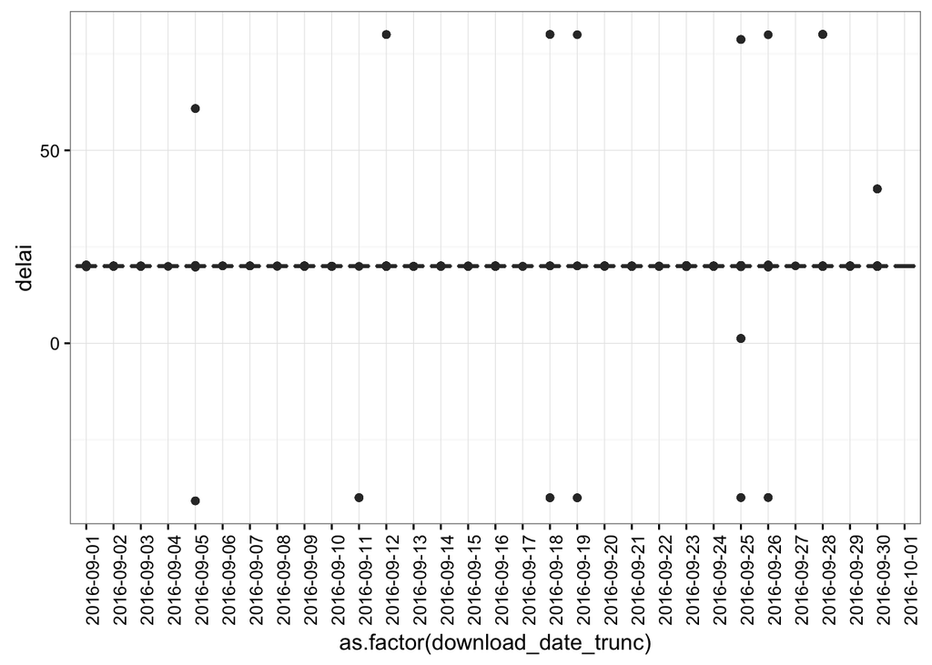

```r
sample.delai.enreg <- delai.enreg[sample(1:nrow(delai.enreg), 10000),]
ggplot(sample.delai.enreg) + aes(x=as.factor(download_date_trunc), y=delai) + geom_boxplot() +  theme_bw() + theme(axis.text.x = element_text(angle = 90))
```

On regarde combien de stations et combien de station.jour sont concernées par un délai supérieur à 60 minutes entre 2 enregistrements.

```r
length(unique(subset(delai.enreg, delai > 60)$number))
```

```
## [1] 1222
```

```r
nrow(delai.enreg %>%
       filter(delai > 60) %>%
       select(number, download_date_trunc) %>%
       distinct)
```

```
## [1] 8550
```

```r
nrow(delai.enreg %>%
       select(number, download_date_trunc) %>%
       distinct)
```

```
## [1] 37860
```

#### Vérification : bike_stands = available_bike_stands + available_bikes

```r
df.octobre <- df.octobre %>%
  mutate(is_ecart = ifelse(bike_stands != available_bike_stands + available_bikes, 1, 0),
         prop_ecart = round(abs(bike_stands - (available_bike_stands + available_bikes))/bike_stands, 4))

table(df.octobre$is_ecart)
```

```
##
##       0       1
## 1942417  693049
```

```r
summary(subset(df.octobre, is_ecart == 1)$prop_ecart)
```

```
##    Min. 1st Qu.  Median    Mean 3rd Qu.    Max.
##  0.0139  0.0278  0.0435  0.1288  0.0714  6.0000
```

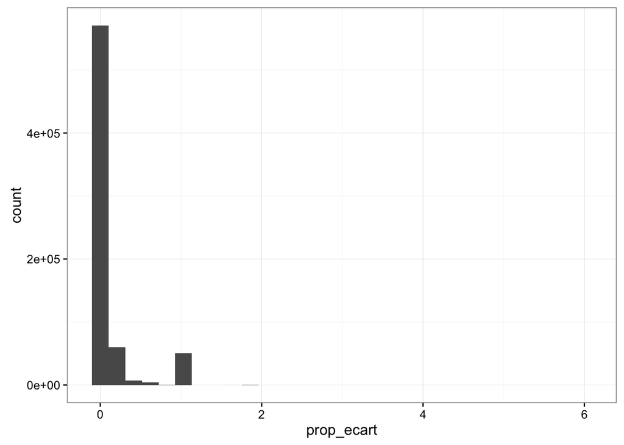

```r
ggplot(subset(df.octobre, is_ecart == 1)) + aes(x=prop_ecart) + geom_histogram() + theme_bw()
```

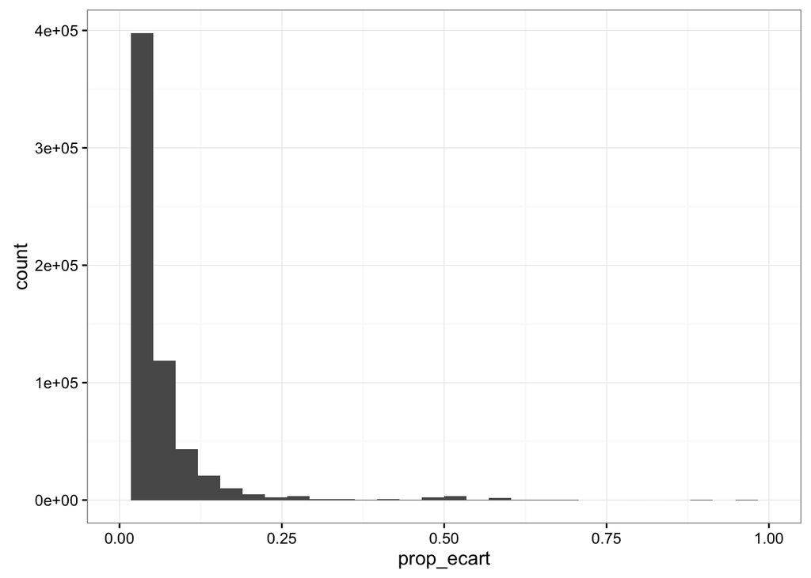

```r
ggplot(subset(df.octobre, is_ecart == 1)) + aes(x=prop_ecart) + geom_histogram() + xlim(c(0,1)) + theme_bw()
```

La proportion d’enregistrements ayant un écart est importante, mais cet écart est généralement assez faible.

# Observation de l’indicateur taux de vélos disponibles sur quelques exemples

```r
load("Donnees/stations.RData")
df.octobre.obs <- inner_join(df.octobre, stations)
df.octobre.obs <- df.octobre.obs %>%
  mutate(taux_dispo = available_bikes / bike_stands)
```

Fonction de visualisation d’un profil

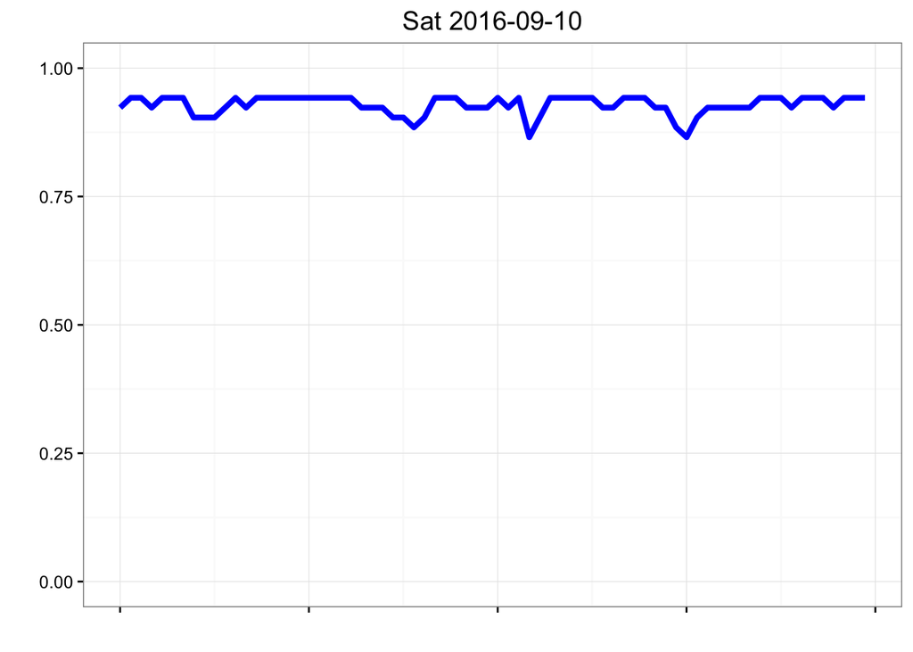

```r
profil.visu <- function(numero, date){
  numero=as.character(numero)
  date=as.Date(date, format="%Y-%m-%d")
  df.obs <- df.octobre.obs %>%
    filter(number == numero & as.Date(download_date, tz="Europe/Paris") == date)
  # plot(taux_dispo~download_date, df.obs, type="b", ylim=c(0,1))
  ggplot(df.obs) + aes(x=download_date, y=taux_dispo) + geom_line(size=1.5, col="blue") + ylim(c(0,1)) + ggtitle(paste(wday(date, label = TRUE), date)) + xlab("") + ylab("") + theme_bw() + theme(axis.text.x=element_blank())
}

profil.visu(3001, "2016-09-10")
```

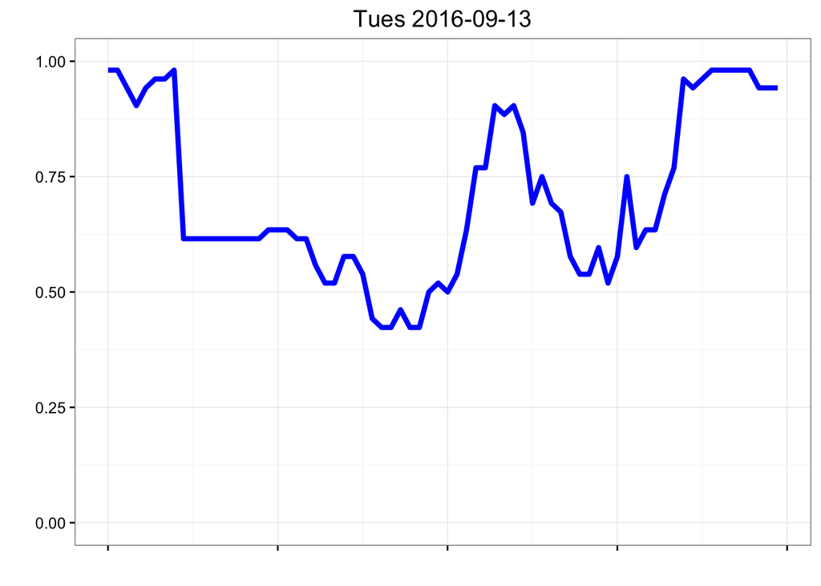

```r
profil.visu(3001, "2016-09-13")
```

```r
profil.visu.compare <- function(numero, dates){
  plots=list()
  for(d in 1:length(dates)){
    plots[[d]]=profil.visu(numero, dates[d])
  }
  marrangeGrob(plots, nrow=2, ncol=round(length(plots)/2))
}
```

On regarde quelques exemples de stations. Par exemple, à proximité de la BNF, lieu de travail et d’étude.

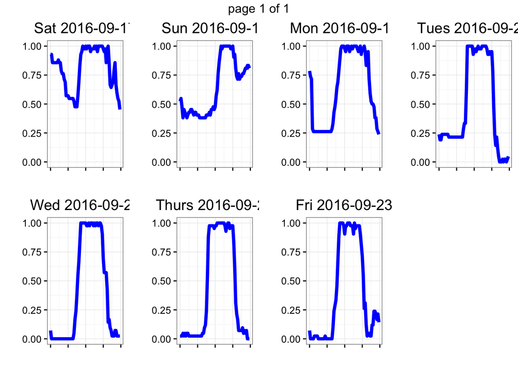

```r
sem1=seq(as.Date("2016-09-03"), as.Date("2016-09-09"), by="day")
sem2=seq(as.Date("2016-09-10"), as.Date("2016-09-16"), by="day")
sem3=seq(as.Date("2016-09-17"), as.Date("2016-09-23"), by="day")
sem4=seq(as.Date("2016-09-24"), as.Date("2016-09-30"), by="day")
profil.visu.compare(13123, sem3)
```

A proximité d’Alesia, lieu résidentiel

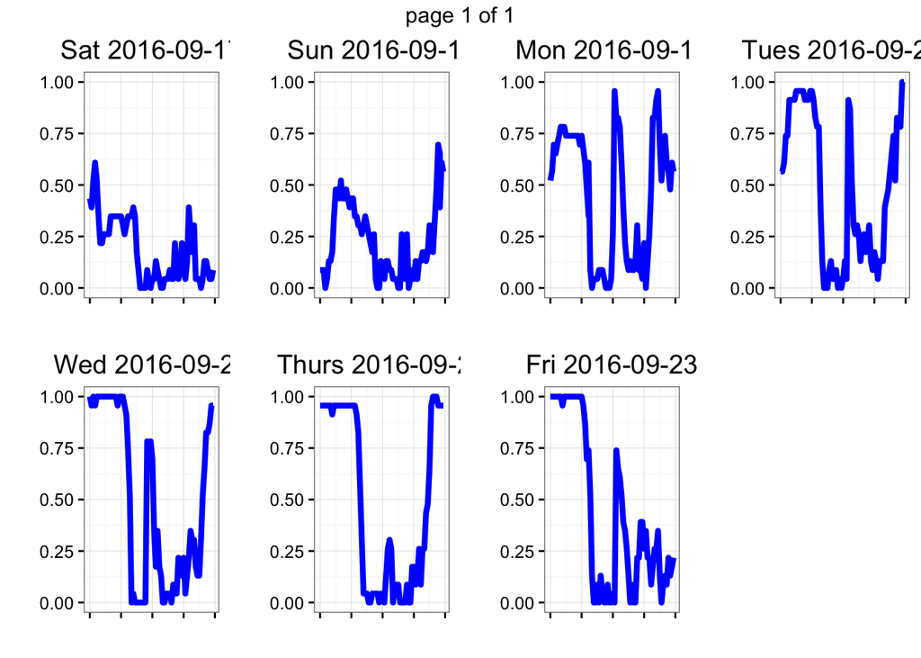

```r
profil.visu.compare(14011, sem3)
```

A proximité de la tour eiffel, lieu touristique.

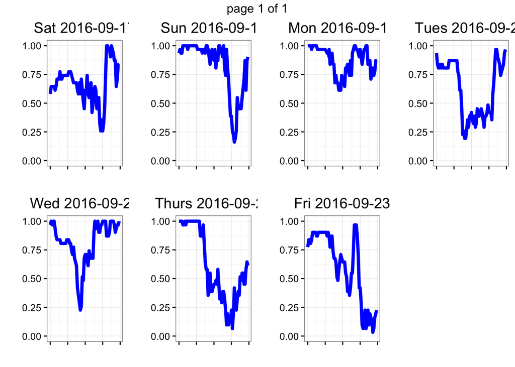

```r
profil.visu.compare(7024, sem3)
```

A proximité du parc de vincennes

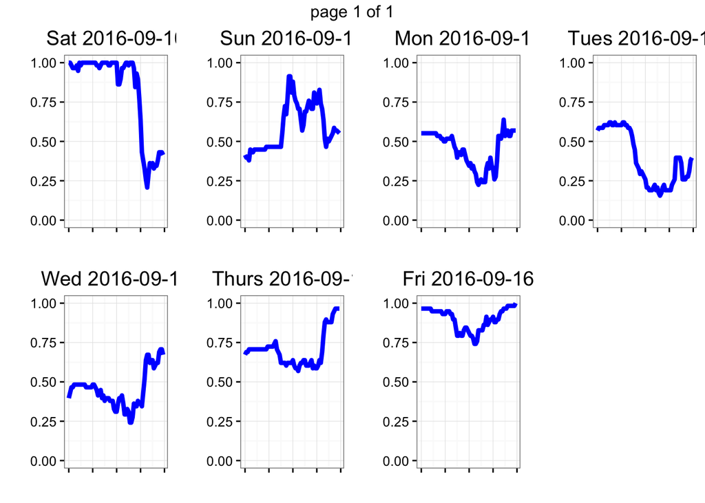

```r
profil.visu.compare(12041, sem2)
```